# Getting started with genridge

Michael Friendly

2026-11-20

The **genridge** package provides ridge regression with graphical methods that show both the *bias* (shrinkage) and the *precision* (inverse variance) of the estimated coefficients (Friendly 2013). This vignette introduces the main functions with two examples.

## What is ridge regression?

Consider the standard linear model, $\mathbf{y} = \mathbf{X} \boldsymbol{\beta} + \boldsymbol{\epsilon}$, for $p$ predictors. When the predictors are highly correlated, ordinary least squares (OLS) suffers from the well-known problems of *collinearity*: the estimates of $\boldsymbol{\beta}$ are unstable, their standard errors are inflated, and the estimated coefficients tend to be too large in absolute value.

The OLS estimates, which minimize the residual sum of squares, are

$$\widehat{\boldsymbol{\beta}}^{\mathrm{OLS}} = (\mathbf{X}^\top
\mathbf{X})^{-1} \mathbf{X}^\top \mathbf{y} \enspace ,$$

with $\widehat{\text{Var}} (\widehat{\boldsymbol{\beta}}^{\mathrm{OLS}}) = \widehat{\sigma}^2 (\mathbf{X}^\top \mathbf{X})^{-1}$. Ridge regression (Hoerl and Kennard 1970) replaces the residual sum of squares by a penalized form,

$$\mathrm{RSS}(\lambda) = (\mathbf{y}-\mathbf{X} \boldsymbol{\beta})^\top
(\mathbf{y}-\mathbf{X} \boldsymbol{\beta}) + \lambda
\boldsymbol{\beta}^\top \boldsymbol{\beta} \quad\quad (\lambda \ge 0)
\enspace ,$$

whose solution is

$$\widehat{\boldsymbol{\beta}}^{\mathrm{RR}}_\lambda = (\mathbf{X}^\top
\mathbf{X} + \lambda \mathbf{I})^{-1} \mathbf{X}^\top \mathbf{y}
\enspace .$$

The *ridge constant* $\lambda$ adds a small amount to the diagonal of $\mathbf{X}^\top \mathbf{X}$, which shrinks the coefficients toward zero. Shrinkage can also be expressed as the equivalent **effective degrees of freedom**, $\text{df}(\lambda) = \text{tr}[\mathbf{X} (\mathbf{X}^\top \mathbf{X} + \lambda \mathbf{I})^{-1} \mathbf{X}^\top]$, which decreases from $p$ (OLS, $\lambda = 0$) as $\lambda$ increases. In general,

- the **bias** of the estimates increases as $\lambda$ increases, but
- their **sampling variance** decreases as $\lambda$ increases.

A main goal of genridge is to *visualize* this tradeoff, to help understand what ridge regression does and to choose a value of $\lambda$.

## What genridge provides

**Fitting.** `ridge()` fits ridge regression models for a vector of ridge constants (`lambda`) or of effective degrees of freedom (`df`). It can be called with

- a model formula and data frame: `ridge(y ~ x1 + x2, data, lambda = )`,
- a response vector and a matrix of predictors: `ridge(y, X, lambda = )`, or
- a model already fitted by `lm()`: `ridge(lm(y ~ x1 + x2, data), lambda = )`.

Predictors are centered and scaled (to unit mean square) before fitting, as in `MASS::lm.ridge()`, so the coefficients are on the scale of the standardized predictors. Most importantly, `ridge()` also calculates the **covariance matrices** of the estimated coefficients for each value of $\lambda$, so that their precision can be studied and displayed.

**Computation and summaries.**

- `coef()`, `vcov()`, `print()`: coefficients and their covariance matrices
- `best()`: optimal ridge constants according to the HKB, LW and GCV criteria
- `vif()`: variance inflation factors, for each value of $\lambda$
- `precision()`: measures of the precision and shrinkage of the coefficients
- `pca()`: transform the results to the space of the principal components (SVD) of the predictors

**Plots.**

- `traceplot()`: the traditional univariate ridge trace plot
- `plot()`: bivariate ridge trace plots, with covariance ellipses of the coefficients
- `pairs()`: all pairwise bivariate ridge trace plots
- `plot3d()`: 3D ridge trace plots, with covariance ellipsoids (using **rgl**)
- `biplot()`: bivariate ridge trace plots in PCA space, with vectors for the predictors
- `plot()` methods for the results of `vif()` and `precision()`

## Example: Longley’s data

The classic example for ridge regression is Longley’s (1967) data, `datasets::longley`: 7 economic variables, observed yearly from 1947 to 1962 ($n = 16$). The goal is to predict `Employed` from `GNP`, `Unemployed`, `Armed.Forces`, `Population`, `Year` and `GNP.deflator`. These data, constructed to illustrate numerical problems in least squares software of the time, are purposely perverse:

- each variable is a time series, so there is a clear lack of independence;
- worse, several predictors are *structurally* collinear: `GNP`, `Year`, `GNP.deflator` and `Population` all grow over time, and `GNP.deflator` is a multiplicative factor to account for inflation.

```r
data(longley)
str(longley)
```

```
#> 'data.frame':    16 obs. of  7 variables:
#>  $ GNP.deflator: num  83 88.5 88.2 89.5 96.2 ...
#>  $ GNP         : num  234 259 258 285 329 ...
#>  $ Unemployed  : num  236 232 368 335 210 ...
#>  $ Armed.Forces: num  159 146 162 165 310 ...
#>  $ Population  : num  108 109 110 111 112 ...
#>  $ Year        : int  1947 1948 1949 1950 1951 1952 1953 1954 1955 1956 ...
#>  $ Employed    : num  60.3 61.1 60.2 61.2 63.2 ...
```

### Fitting ridge regression models

We fit models for six values of the ridge constant, approximately equally spaced on a log scale, where $\lambda = 0$ gives the OLS estimates.

```r
lambda <- c(0, 0.005, 0.01, 0.02, 0.04, 0.08)
lform <- Employed ~ GNP + Unemployed + Armed.Forces + Population + Year + GNP.deflator
lridge <- ridge(lform, data = longley, lambda = lambda)
lridge
```

```
#> Ridge Coefficients:
#>        GNP        Unemployed  Armed.Forces  Population  Year       GNP.deflator
#> 0.000  -3.447192  -1.827886   -0.696210     -0.344197    8.431972   0.157380
#> 0.005  -1.042478  -1.491395   -0.623468     -0.935580    6.566532  -0.041750
#> 0.010  -0.179797  -1.361047   -0.588140     -1.003168    5.656287  -0.026122
#> 0.020   0.499494  -1.245137   -0.547633     -0.867553    4.626116   0.097663
#> 0.040   0.905947  -1.155229   -0.503911     -0.523471    3.576502   0.321240
#> 0.080   1.090705  -1.086421   -0.458252     -0.085963    2.641649   0.570252
```

The same model can be fitted from a response vector and predictor matrix, or from a model already fitted with `lm()`:

```r
lridge2 <- ridge(longley$Employed, data.matrix(longley[, c(2:6, 1)]), lambda = lambda)
longley.lm <- lm(lform, data = longley)
lridge3 <- ridge(longley.lm, lambda = lambda)
all.equal(coef(lridge), coef(lridge3))
```

```
#> [1] TRUE
```

Instead of `lambda`, the amount of shrinkage can be specified by the effective degrees of freedom, which is often easier to interpret: here, `df = 6` corresponds to OLS, and smaller values to more shrinkage.

```r
lridge.df <- ridge(lform, data = longley, df = c(6, 5.5, 5, 4.5, 4))
lridge.df$lambda
```

```
#> [1] 0.000000 0.003928 0.013579 0.038270 0.103073
```

Both `lambda` and `df` are stored in the `"ridge"` object, so plots can use either.

### Choosing the ridge constant

Several criteria have been proposed for choosing a value of $\lambda$ to balance bias against precision. `ridge()` calculates three, and `best()` collects them, with the corresponding effective degrees of freedom:

- **HKB**: Hoerl, Kennard, and Baldwin (1975)
- **LW**: Lawless and Wang (1976)
- **GCV**: the value of `lambda` minimizing generalized cross-validation (Golub, Heath, and Wahba 1979), among those supplied

```r
best(lridge)
```

```
#>            k    df
#> HKB 0.004275 5.471
#> LW  0.032295 4.585
#> GCV 0.005000 5.415
```

These values seem small, but as we will see, some of the coefficients are shrunk considerably even by these.

### Collinearity: variance inflation factors

The effect of collinearity on the precision of each coefficient is measured by its variance inflation factor,

$$\text{VIF}(\beta_i) = \frac{1}{1 - R^2_{i | \text{others}}} \enspace ,$$

where $R^2_{i | \text{others}}$ is the squared multiple correlation of predictor $i$ with all the others. `vif()` calculates these for each value of $\lambda$. For OLS (the first row), nearly all are dangerously high; ridge regression reduces them rapidly.

```r
vridge <- vif(lridge)
vridge
```

```
#> Variance inflaction factors:
#>            GNP  Unemployed  Armed.Forces  Population    Year  GNP.deflator
#> 0.000  1788.51      33.619         3.589      399.15  758.98        135.53
#> 0.005   540.04      12.118         2.921      193.30  336.15         90.63
#> 0.010   259.00       7.284         2.733      134.42  218.84         74.79
#> 0.020   101.12       4.573         2.578       87.29  128.82         58.94
#> 0.040    34.43       3.422         2.441       52.22   66.31         43.56
#> 0.080    11.28       2.994         2.301       28.59   28.82         29.52
```

The `plot()` method shows how they decrease, here on the scale of $\sqrt{\text{VIF}}$ (the factor by which the standard error is inflated) against the effective degrees of freedom:

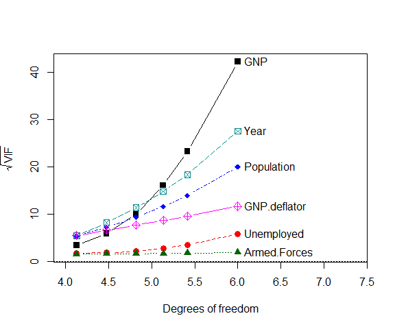

Square root of variance inflation factors against effective degrees of freedom.

```r
clr <- c("black", "red", "darkgreen", "blue", "cyan4", "magenta")
pch <- c(15:18, 7, 9)
plot(vridge, X = "df", Y = "sqrt", col = clr, pch = pch, cex = 1.2, xlim = c(4, 6.5))
```

### Univariate ridge trace plots

The standard ridge trace plot simply shows the estimated coefficients for each predictor against the ridge constant. The dotted vertical lines show the values of the HKB and LW criteria.

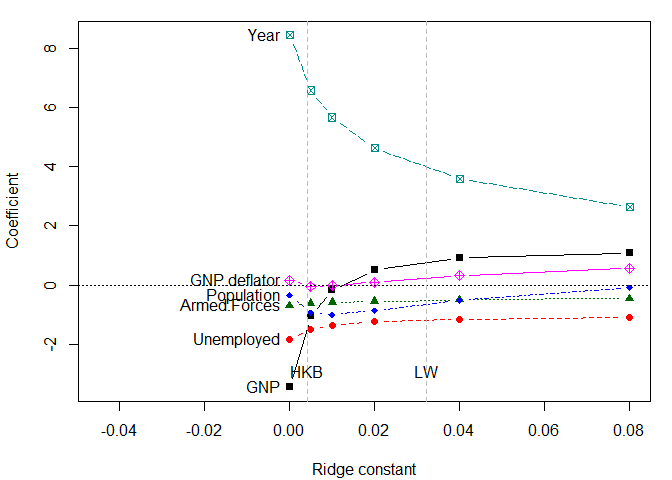

Univariate ridge trace plot for the coefficients of predictors of Employed in Longley’s data.

```r
traceplot(lridge, xlim = c(-0.02, 0.08))
```

It is often easier to interpret this plot against the effective degrees of freedom, which spaces the values of $\lambda$ more evenly:

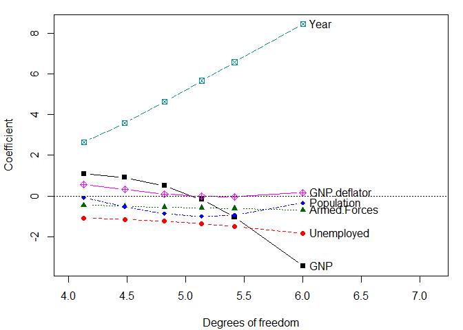

Univariate ridge trace plot of the coefficients against effective degrees of freedom.

```r
traceplot(lridge, X = "df", xlim = c(4, 6.5))
```

**But this is the wrong plot!** It shows the bias that increases with $\lambda$, but **not** the accompanying decrease in variance, which is the reason for using ridge regression. The univariate trace plot is the wrong graphic form for what is essentially a *multivariate* problem: we want to see how *both* the coefficients and their variances and covariances change with $\lambda$.

### Bivariate ridge trace plots

The bivariate analog of the trace plot (Friendly 2013) shows **covariance ellipses** for pairs of coefficients. Their centers, $(\widehat{\beta}_i, \widehat{\beta}_j)$, are the estimated coefficients, and their size and shape show the sampling variances and covariance of these estimates. Here, we plot `GNP` against four of the other predictors.

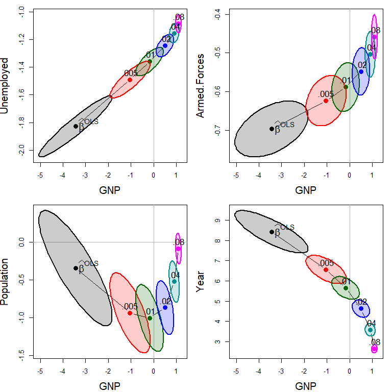

Bivariate ridge trace plots for the coefficients of four predictors against that for GNP in Longley’s data.

```r
op <- par(mfrow = c(2, 2), mar = c(4, 4, 1, 1) + 0.1)
lambdaf <- c(expression(~widehat(beta)^OLS), ".005", ".01", ".02", ".04", ".08")
for (i in 2:5) {
  plot(lridge, variables = c(1, i),
       radius = 0.5, cex.lab = 1.5, col = clr,
       labels = NULL, fill = TRUE, fill.alpha = 0.2)
  text(lridge$coef[1, 1], lridge$coef[1, i],
       expression(~widehat(beta)^OLS), cex = 1.5, pos = 4, offset = .1)
  text(lridge$coef[-1, c(1, i)], lambdaf[-1], pos = 3, cex = 1.3)
}
```

```r
par(op)
```

The coefficients for each pair of predictors trace a path generally toward the origin, $(0, 0)$, and the covariance ellipses become smaller, showing the increase in precision. These plots also show the *bivariate* path of shrinkage, which is often far from a straight line toward the origin. For the ideas behind such “elliptical thinking” in statistics, see Friendly, Monette, and Fox (2013).

The `pairs()` method shows all pairwise views in a scatterplot matrix:

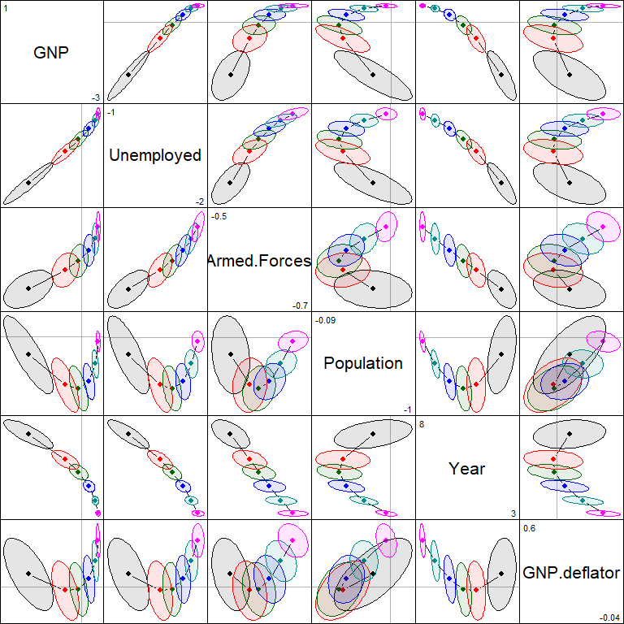

Scatterplot matrix of bivariate ridge trace plots.

```r
pairs(lridge, radius = 0.5, diag.cex = 2, fill = TRUE, fill.alpha = 0.1)
```

`plot3d()` extends this to three dimensions, drawing covariance ellipsoids for three predictors with **rgl**. Here we choose `GNP`, `Year` and `Population`, the predictors with the largest VIFs. Because they are nearly collinear, the OLS ellipsoid is long and thin, pointing in a direction where the data say little about the separate coefficients; ridge regression shrinks it most along that direction. In an R session, `plot3d()` opens an interactive window; here, `rgl::rglwidget()` embeds the scene in the page. Drag to rotate it, and scroll to zoom.

```r
plot3d(lridge, variables = c("GNP", "Year", "Population"), radius = 0.5)
rgl::rglwidget(width = 700, height = 650)
```

[interactive chart not shown]

### Visualizing the bias-variance tradeoff

`precision()` calculates measures of the effect of shrinkage on the sampling variance of the coefficients. Larger $\lambda$ should lead to smaller $\widehat{\text{Var}} (\widehat{\boldsymbol{\beta}})$, i.e., greater precision.

```r
pridge <- precision(lridge)
pridge
```

```
#>       lambda    df    det   trace max.eig norm.beta norm.diff
#> 0.000  0.000 6.000 -12.93 18.1190 15.4191    1.0000     0.000
#> 0.005  0.005 5.415 -14.41  6.8209  4.6065    0.7406     1.276
#> 0.010  0.010 5.135 -15.41  4.0423  2.1807    0.6365     1.783
#> 0.020  0.020 4.818 -16.83  2.2180  1.0255    0.5282     2.262
#> 0.040  0.040 4.478 -18.70  1.1647  0.5808    0.4233     2.679
#> 0.080  0.080 4.128 -21.05  0.5873  0.2599    0.3373     3.027
```

Among these, `norm.beta` $= \lVert\boldsymbol{\beta}\rVert / \max{\lVert\boldsymbol{\beta}\rVert}$ measures shrinkage, and `det` $= \log{| \text{Var}(\boldsymbol{\beta}) |}$ measures the variance of the coefficients (the inverse of precision); see `help(precision)` for the others. Plotting them against each other gives a direct view of the tradeoff between bias and precision. The `plot()` method also marks the values given by the HKB and LW criteria:

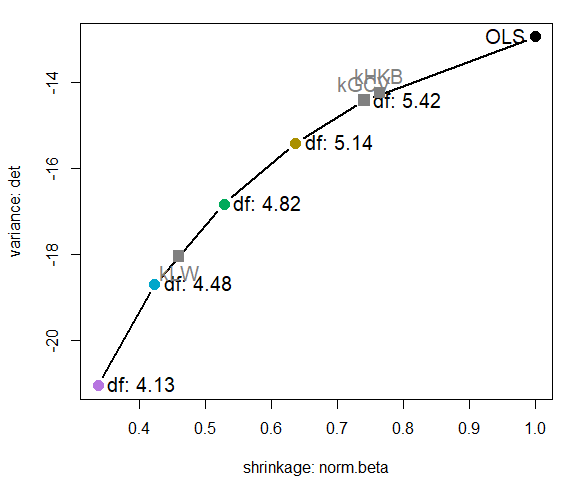

Variance (log determinant) vs. shrinkage, showing the tradeoff between bias and variance. Points are labeled with the effective degrees of freedom.

```r
plot(pridge, labels = "df", label.prefix = "df:", criteria = lridge$criteria)
```

### Low-rank views: ridge regression in PCA space

Just as principal components analysis (PCA) gives low-dimensional views of a data set, it helps to understand ridge regression. `pca()` transforms a `"ridge"` object from the space of the predictors to the space of the principal components of $\mathbf{X}$, given by its singular value decomposition.

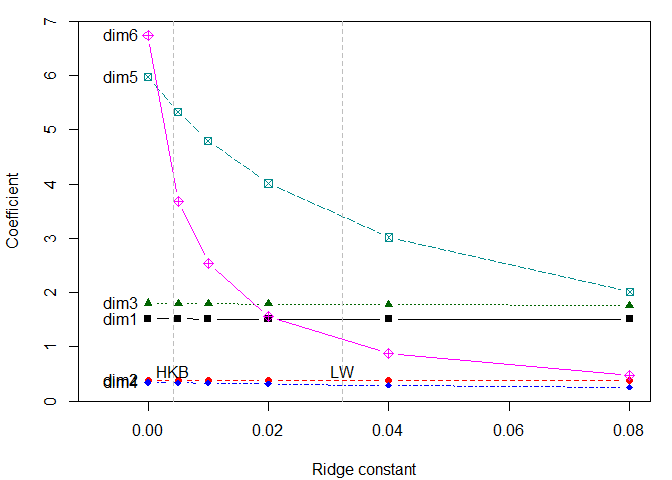

Ridge trace plot for the coefficients in PCA space.

```r
plridge <- pca(lridge)
traceplot(plridge)
```

What may be surprising is that the coefficients for the first three components are hardly shrunk at all, even at the largest $\lambda$ (by 0–2%), and the fourth only moderately. Most of the shrinkage is on the *last two dimensions*, which correspond to the smallest singular values: their coefficients are reduced to about 1/3 and 1/14 of their OLS values. These are the directions that contribute most to collinearity (Friendly and Kwan 2009). Because the principal components are uncorrelated, the ellipses in this space are aligned with the coordinate axes:

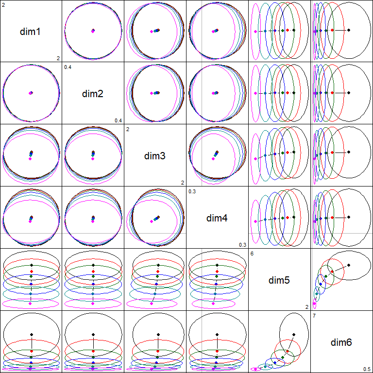

Scatterplot matrix of bivariate ridge trace plots in PCA space.

```r
pairs(plridge)
```

The **biplot** view projects the original predictors into the space of the two smallest dimensions, where the shrinkage happens, as vectors showing how they contribute to these dimensions. Here, `Year` and `Population` contribute mainly to dimension 5, and a contrast between (`Year`, `Population`) and `GNP` to dimension 6.

```r
biplot(plridge, radius = 0.5, ref = FALSE, asp = 1,
       var.cex = 1.15, cex.lab = 1.3, col = clr,
       fill = TRUE, fill.alpha = 0.2, prefix = "Dimension ")
```

```
#> Vector scale factor set to  5.247
```

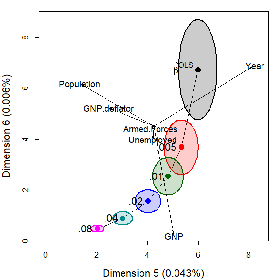

Biplot view of the ridge trace plot for the two smallest dimensions.

```r
text(plridge$coef[, 5:6], lambdaf, pos = 2, cex = 1.3)
```

## Example: Detroit homicide data

The `Detroit` data, used extensively by Miller (2002), give the number of homicides per 100,000 population in Detroit from 1961 to 1973, with 13 potential predictors. Following Miller, we use the “best” six-variable model, with predictors standardized for comparison, and specify the amount of shrinkage by the effective degrees of freedom.

```r
data(Detroit)
Det <- as.data.frame(scale(Detroit[, c(1, 2, 4, 6, 7, 11)]))
Det <- cbind(Det, Homicide = Detroit[, "Homicide"])
dridge <- ridge(Homicide ~ ., data = Det, df = seq(6, 4, -0.5))
vif(dridge)
```

```
#> Variance inflaction factors:
#>          Police  Unemp  GunLic  HClear  WhMale  WkEarn
#> 0.00000  24.813  4.857  19.272  46.923  56.711  54.717
#> 0.03902  20.119  3.870  11.362  33.072  35.390  31.883
#> 0.10082  15.415  2.971   6.432  21.289  20.776  17.353
#> 0.20586  10.776  2.208   3.597  12.171  11.258   8.750
#> 0.40332   6.534  1.623   2.128   5.996   5.503   4.113
```

The univariate ridge trace plot shows something that seems paradoxical: the coefficients for `Police`, `HClear` and `WhMale` do not shrink toward zero as $\lambda$ increases, but grow *away* from it.

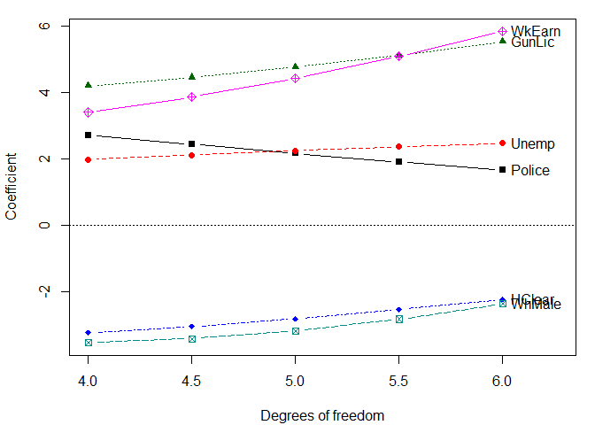

Univariate ridge trace plot for the Detroit data. Some coefficients move away from zero.

```r
traceplot(dridge, X = "df")
```

This is not a contradiction. Ridge regression shrinks the *length* of the whole vector of coefficients, $\lVert \boldsymbol{\beta} \rVert$, not each coefficient separately; when predictors are highly correlated, the coefficients of some can grow as others shrink. The bivariate plots show the joint paths:

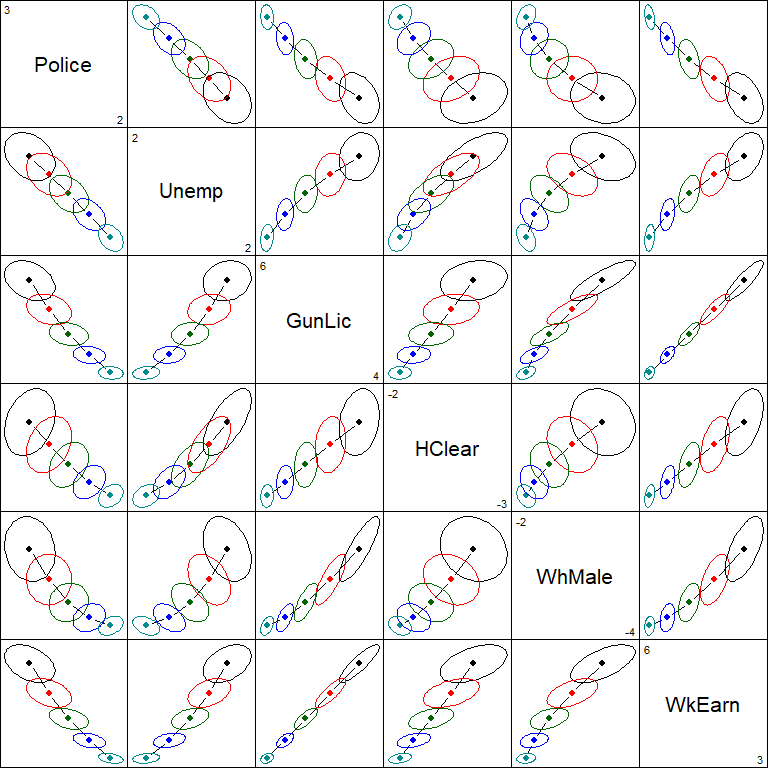

Bivariate ridge trace plots for the Detroit data.

```r
pairs(dridge, radius = 0.5)
```

In PCA space, the behavior is no longer paradoxical: every component’s coefficient shrinks toward zero, by an amount that is greatest for the components with the smallest singular values (dimension 6 is reduced from 4.1 to 0.9, while dimension 1 hardly changes).

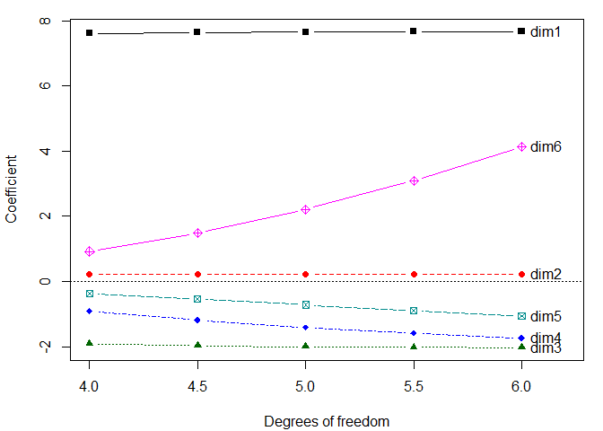

Ridge trace plot for the Detroit data in PCA space.

```r
dpridge <- pca(dridge)
traceplot(dpridge, X = "df")
```

## Other examples

The package includes several other data sets, each with examples: `Acetylene` (collinearity created by polynomial and interaction terms), `Manpower` (extreme collinearity among hospital workload measures), `prostate` (the prostate cancer data used as a running example in Hastie, Tibshirani and Friedman’s *The Elements of Statistical Learning*), and `diab` (diabetes progression, from Efron and Hastie’s *Computer Age Statistical Inference*). Try, e.g., `example(Manpower)`.

## Multivariate ridge regression (experimental)

`ridge()` also accepts a *matrix* of several responses, e.g., `ridge(cbind(Y1, Y2) ~ x1 + x2, data)`, fitting all responses with the same ridge constants. This extension is **experimental** in this version. It is described in the article “Multivariate ridge regression” on the package website; see also `help("as.ridge")` and `help("mlmridge-plots")`.

## Related packages

Other R packages fit ridge regression models: `MASS::lm.ridge()`, **glmnet** (ridge as the $\alpha = 0$ case of the elastic net) and **lmridge**. genridge focuses on *visualizing* the bias (shrinkage) and precision of the estimates. **lmridge** (Imdad Ullah, Aslam, and Altaf 2018) is the place to go for a long list of estimators of the ridge constant, tests, and other ridge statistics.

## References

Friendly, Michael. 2013. “The Generalized Ridge Trace Plot: Visualizing Bias *and* Precision.” *Journal of Computational and Graphical Statistics* 22 (1): 50–68. https://doi.org/10.1080/10618600.2012.681237.

Friendly, Michael, and Ernest Kwan. 2009. “Where’s Waldo: Visualizing Collinearity Diagnostics.” *The American Statistician* 63 (1): 56–65. https://doi.org/10.1198/tast.2009.0012.

Friendly, Michael, Georges Monette, and John Fox. 2013. “Elliptical Insights: Understanding Statistical Methods Through Elliptical Geometry.” *Statistical Science* 28 (1): 1–39. https://doi.org/10.1214/12-STS402.

Golub, Gene H., Michael Heath, and Grace Wahba. 1979. “Generalized Cross-Validation as a Method for Choosing a Good Ridge Parameter.” *Technometrics* 21 (2): 215–23. https://doi.org/10.1080/00401706.1979.10489751.

Hoerl, Arthur E., and Robert W. Kennard. 1970. “Ridge Regression: Biased Estimation for Nonorthogonal Problems.” *Technometrics* 12: 55–67.

Hoerl, Arthur E., Robert W. Kennard, and Kent F. Baldwin. 1975. “Ridge Regression: Some Simulations.” *Communications in Statistics* 4 (2): 105–23. https://doi.org/10.1080/03610927508827232.

Imdad Ullah, Muhammad, Muhammad Aslam, and Saima Altaf. 2018. “lmridge: A Comprehensive R Package for Ridge Regression.” *The R Journal* 10 (2): 326–43. https://doi.org/10.32614/RJ-2018-060.

Lawless, Jerald F., and P. Wang. 1976. “A Simulation Study of Ridge and Other Regression Estimators.” *Communications in Statistics* 5: 307–23.

Longley, James W. 1967. “An Appraisal of Least Squares Programs for the Electronic Computer from the Point of View of the User.” *Journal of the American Statistical Association* 62: 819–41. https://doi.org/10.1080/01621459.1967.10500896.

Miller, Alan J. 2002. *Subset Selection in Regression*. 2nd ed. Boca Raton, FL: Chapman & Hall/CRC.